# FigureYa147interaction

**Author(s)**: Zongcheng Li  
**Reviewer(s)**: Ying Ge, Junyi Shen  
**Date**: 2025-12-03

## 1 Academic Citation

If you use this code in your work or research, we kindly request that you cite our publication:

Xiaofan Lu, et al. (2025). FigureYa: A Standardized Visualization Framework for Enhancing Biomedical Data Interpretation and Research Efficiency. iMetaMed. https://doi.org/10.1002/imm3.70005

To cite database ‘ComPPI’ in publications use:

Veres, D., Gyurko, M. D., Thaler, B., Szalay, K., Fazekas, D., Korcsmaros, T. and Csermely, P. (2015) ComPPI: a cellular compartment-specific database for protein-protein interaction network analysis. Nucleic Acids Res. (Database Issue) 43, D485-D493. http://arxiv.org/abs/1410.2494

## 2 需求描述 Requirements description

用interaction文件作为输入画调控网络图，线的长短与相互作用score对应，线的数量和颜色与证据对应。 Use the interaction file as input to draw a regulatory network diagram. The length of the line corresponds to the interaction score, and the number and color of the line correspond to the evidence.

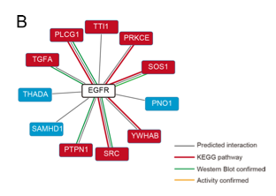

From https://www.ncbi.nlm.nih.gov/pmc/articles/PMC4951236

这篇文章用matlab写了个脚本OncoBinder.m，free online，能根据多种数据找interaction、打分、画图，感兴趣的小伙伴写信给文章作者吧～ This article uses Matlab to write a script OncoBinder.m, which is free online and can find interactions, score, and draw diagrams based on a variety of data. Interested friends can write to the author of the article~

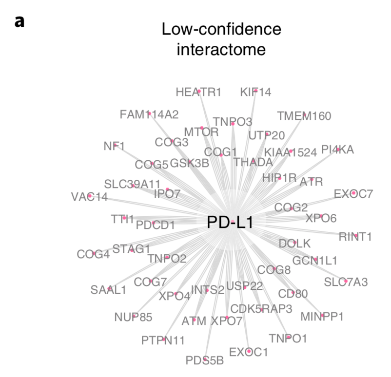

From https://www.nature.com/articles/s41589-018-0161-x

Fig. 1 | Identification of HIP1R as a regulator of PD-L1. a, Schematic representation of the identification process. A set of low-confidence interactors of PD-L1 according to high-throughput assays (left panel) were analyzed by the OncoBinder model (middle panel) to identify functionally relevant interactions. The ‘co-activation’ scores of candidate interactors are plotted in the right panel, with statistically significant associations marked in red (P < 0.01, Pearson correlation, two-sided). The modeling experiment was replicated for three times with the same results obtained.

**图的解析** **Analysis of the graph**

用改写的OncoBinder（没有提供脚本）找interaction并画图。中央是PD-L1，周围是跟它有相互作用关系的蛋白质。 Use the rewritten OncoBinder (no script provided) to find the interaction and draw the graph. PD-L1 is in the center, and the proteins that interact with it are around it.

Figure legend和正文都没有描述线的长短和数量与哪个特征相对应。 Neither the figure legend nor the text describes which feature the length and number of lines correspond to.

我们结合这两幅图设计了下面的图，设计思路看这篇：https://mp.weixin.qq.com/s/cQzsw1DKTUqooBmE078k2A We combined these two graphs to design the following graph. For the design ideas, see this article: https://mp.weixin.qq.com/s/cQzsw1DKTUqooBmE078k2A

## 3 应用场景 Application scenarios

展示相互作用关系，同时展示相互作用证据的来源和打分。 Show the interaction relationship, and at the same time show the source and score of the interaction evidence.

像例文中的蛋白相互作用，或转录因子-靶基因，或miRNA-靶基因的关系。 Like the protein interaction in the example text, or the relationship between transcription factor-target gene, or miRNA-target gene.

其中转录因子-靶基因的关系可以这样设计：中央画转录因子，周围画靶基因；连线代表各种证据例如有motif、有ATAC-seq的peak、有H3K27ac的peak等等；自己给这些证据权重，计算一个总体的打分作为连线的长度。 The relationship between transcription factor-target gene can be designed as follows: draw the transcription factor in the center and the target gene around it; the connecting line represents various evidences such as motif, ATAC-seq peak, H3K27ac peak, etc.; give these evidence weights by yourself and calculate an overall score as the length of the connecting line.

## 4 环境设置 Environment settings

```r
source("install_dependencies.R")
```

```
## Starting R package installation...
## ===========================================
##
## Installing CRAN packages...
## Package already installed: ggplot2
## Package already installed: igraph
## Package already installed: magrittr
## Package already installed: reshape2
##
## Installing Bioconductor packages...
## Package already installed: clusterProfiler
## Package already installed: org.Hs.eg.db
##
## ===========================================
## Package installation completed!
## You can now run your R scripts in this directory.
```

```r
library(org.Hs.eg.db)         # 加载人类基因注释数据库｜Load human gene annotation database
library(clusterProfiler)      # 加载富集分析工具包｜Load enrichment analysis toolkit
```

```r
library(ggplot2)              # 加载绘图包｜Load plotting package
library(reshape2)             # 加载数据重塑包｜Load data reshaping package
library(igraph)               # 加载网络分析包｜Load network analysis package
library(magrittr)             # 加载管道操作包｜Load pipe operator package

Sys.setenv(LANGUAGE = "en") #显示英文报错信息 #Display English error message
options(stringsAsFactors = FALSE) #禁止chr转成factor #Disable chr conversion to factor
```

自定义画图函数 Custom drawing function

`fcircle` is built for the white background of PD-L1

```r
mycircle <- function(coords, v=NULL, params) {
  vertex.color <- params("vertex", "color")
  if (length(vertex.color) != 1 && !is.null(v)) {
    vertex.color <- vertex.color[v]
  }
  vertex.size  <- 1/200 * params("vertex", "size")
  if (length(vertex.size) != 1 && !is.null(v)) {
    vertex.size <- vertex.size[v]
  }
  vertex.frame.color <- params("vertex", "frame.color")
  if (length(vertex.frame.color) != 1 && !is.null(v)) {
    vertex.frame.color <- vertex.frame.color[v]
  }
  vertex.frame.width <- params("vertex", "frame.width")
  if (length(vertex.frame.width) != 1 && !is.null(v)) {
    vertex.frame.width <- vertex.frame.width[v]
  }

  mapply(coords[,1], coords[,2], vertex.color, vertex.frame.color,
         vertex.size, vertex.frame.width,
         FUN=function(x, y, bg, fg, size, lwd) {
           symbols(x=x, y=y, bg=bg, fg=fg, lwd=lwd,
                   circles=size, lheight = 30, add=TRUE, inches=FALSE)
         })
}

add.vertex.shape("fcircle", clip=igraph.shape.noclip,
         plot=mycircle, parameters=list(vertex.frame.color=1,
                                  vertex.frame.width=1))
```

## 5 参数设置 Parameter settings

```r
# Give your focus official gene_symbol
sourceGene <- "CD274"

# Given name will be shown on the plot instead.
sourceName <- "PD-L1"
```

## 6 输入文件 Input file

如果你已经获得interaction关系，就把自己的数据整理成easy_input.csv文件的格式，跳过这步，直接进入“开始画图”。 If you have already obtained the interaction relationship, organize your data into the format of easy_input.csv file, skip this step and go directly to “Start drawing”.

### 6.1 相互作用文件的下载 Download interaction file

- 数据库。这里用ComPPI数据库检索interaction：Compartmentalized Protein-Protein Interaction Database | v2.1.1, http://comppi.linkgroup.hu/protein_search，适用于人、果蝇、线虫和酵母。
- Database. Here, we use the ComPPI database to search for interactions: Compartmentalized Protein-Protein Interaction Database | v2.1.1, http://comppi.linkgroup.hu/protein_search, which is suitable for humans, fruit flies, nematodes and yeast.

[figure not shown]

其他物种可以用STRING检索，也有score。找更复杂的相互作用关系可参考FigureYa53PPI，用cytoscape画图可参考FigureYa54cytoscape。 Other species can be searched with STRING, and there is also score. For more complex interaction relationships, please refer to FigureYa53PPI, and for drawing with cytoscape, please refer to FigureYa54cytoscape.

- 检索蛋白质”CD274”
- Search for protein “CD274”

[figure not shown]

- 下载interaction文件。As the result of your search query, the following two proteins were found.
- Download interaction file. As the result of your search query, the following two proteins were found.

Q9NZQ7 (UniProtKB-AC) Programmed cell death 1 ligand 1  
Q0GN75 (UniProtKB-AC) CD274

I chose Q0GN75 for use.

[figure not shown]

### 6.2 输入数据的整理 Input data sorting

comppi–interactors_of_Q0GN75.txt，上一步获得的interaction信息。每行一个蛋白质，所有证据和分数都在Major.Loc.With.Loc.Score里面，用｜分隔，需要拆开成每条证据单独一行。

comppi–interactors_of_Q0GN75.txt, interaction information obtained in the previous step. One protein per line, all evidence and scores are in Major.Loc.With.Loc.Score, separated by |, need to be split into a separate line for each piece of evidence.

```r
idata <- read.table(file = "comppi--interactors_of_Q0GN75.txt", sep = "\t", header = T, quote = "")
idata[1:4,]
```

```
##   Interactor                                   Canonical.Name
## 1     Q0GN75                                            CD274
## 2     O75146 Huntingtin-interacting protein 1-related protein
## 3     Q15058                       Kinesin-like protein KIF14
## 4     P21359                                    Neurofibromin
##        Naming.Convention
## 1     UniProtKB/TrEmbl/P
## 2 UniProtKB/Swiss-Prot/P
## 3 UniProtKB/Swiss-Prot/P
## 4 UniProtKB/Swiss-Prot/P
##                                                                            Major.Loc.With.Loc.Score
## 1                                                                                     Membrane(0.8)
## 2 Cytosol(1)|Mitochondrion(0.3)|Nucleus(0.7)|Secretory-pathway(0.86)|Membrane(1)|Extracellular(0.8)
## 3                                      Membrane(0.998)|Cytosol(1)|Nucleus(0.937)|Extracellular(0.8)
## 4                Cytosol(0.981)|Mitochondrion(0.8)|Nucleus(0.79)|Membrane(0.997)|Extracellular(0.8)
```

[output cut: 20 more lines]

```r
# 提取各种证据及其对应的score，每个证据单独一行
# Extract various evidences and their corresponding scores, each evidence in a separate line
ilinks <- NULL
for(i in 1:nrow(idata)){
  for(j in strsplit(idata$Major.Loc.With.Loc.Score[i], split = "\\|")[[1]]){
    tmp <- strsplit(j, split = "\\(")[[1]]
    ilinks <- rbind(ilinks, c(idata$Interactor[i],
                              tmp[1],
                              gsub(pattern = "\\)", "", tmp[2])))
  }
}
colnames(ilinks) <- c("Interactor", "Loc","LocScore")
ilinks <- as.data.frame(ilinks)
head(ilinks)
```

```
##   Interactor               Loc LocScore
## 1     Q0GN75          Membrane      0.8
## 2     O75146           Cytosol        1
## 3     O75146     Mitochondrion      0.3
## 4     O75146           Nucleus      0.7
## 5     O75146 Secretory-pathway     0.86
## 6     O75146          Membrane        1
```

```r
# filter out outlier link
# 这里提取以下6种，实际应用时根据你自己的数据修改
# Extract the following 6 types here, modify according to your own data in actual application
ilinks <- ilinks[ilinks$Loc %in% c("Cytosol", "Secretory-pathway", "Extracellular", "Membrane","Mitochondrion", "Nucleus"),]

# convert uniprot id to gene symbol
idMap <- bitr(idata$Interactor, "UNIPROT", toType = "SYMBOL", OrgDb = org.Hs.eg.db)
ilinks$gene <- idMap$SYMBOL[match(ilinks$Interactor, idMap$UNIPROT)]

# 根据网页提供的公式计算相互作用打分：
# Calculate the interaction score according to the formula provided on the web page:
# http://comppi.linkgroup.hu/help/scores
ilinks$LocScore <- as.numeric(ilinks$LocScore)
locScoreMat <- dcast(ilinks, formula = gene ~Loc, value.var = "LocScore", fun.aggregate = mean)
locScoreMat[is.na(locScoreMat)] <- 0
rownames(locScoreMat) <- locScoreMat$gene
locScoreMat <- locScoreMat[,-1]
locScoreMat$InteractionScore <- 1- apply(locScoreMat[,1:6], 1, function(x) prod(1-x*locScoreMat[sourceGene,]))

# prepare network elements
ilinks$source <- sourceGene
ilinks$target <- ilinks$gene
links <- unique(ilinks[,c("source", "target", "Loc")]) # remove duplicated genes
links <- links[links$target  != sourceGene,] # remove sourceGene
links$score <- locScoreMat[links$target, "InteractionScore"]

# 删除包含 NA 的行
# Remove rows containing NA
links <- links[!is.na(links$score), ]

# 保存到文件
# Save to file
write.csv(links, "easy_input.csv", quote = F, row.names = F)
```

## 7 开始画图 Start drawing

用igraph画图 Drawing with igraph

```r
# 读取相互作用关系和score
# Read the interaction relationship and score
links <- read.csv("easy_input.csv", header = T)
head(links)
```

```
##   source target               Loc score
## 1  CD274  HIP1R           Cytosol   0.8
## 2  CD274  HIP1R     Mitochondrion   0.8
## 3  CD274  HIP1R           Nucleus   0.8
## 4  CD274  HIP1R Secretory-pathway   0.8
## 5  CD274  HIP1R          Membrane   0.8
## 6  CD274  HIP1R     Extracellular   0.8
```

```r
net <- graph_from_data_frame(links, directed = F)

pal_loc <- setNames(RColorBrewer::brewer.pal(7, name = "Set3")[-2],
                      sort(unique(links$Loc)))

# see plot.igraph for more settings
vertexes <- get.vertex.attribute(net, "name")
net %<>%
  set.vertex.attribute("label",
                       value = ifelse(vertexes == sourceGene,
                                      sourceName, vertexes)) %<>%
  set.edge.attribute("color",
                     value = pal_loc[links$Loc]) %<>%
  set.edge.attribute("weight",
                     value = links$score)
set.seed(777)
lay <- layout_with_dh(net) #weight.node.dist = unique(links[,c("target","score")])$score) # weight here may be invalid!

# plot in SVG device, then you may use Adobe Illustrator
# to fine tune the network map.
# Such as adjust the text position to avoid overlapping.

pdf(file = "interaction.pdf", width = 6, height = 8)
plot(net, layout = lay,
     vertex.shape = 'fcircle',
     vertex.size = ifelse(vertexes == sourceGene, 15, 3),
     vertex.color = "hotpink",
     vertex.frame.color = ggplot2::alpha("white", alpha = 0.5),
     vertex.frame.width = ifelse(vertexes == sourceGene, 30, 0.1),
     vertex.label.color = ifelse(vertexes == sourceGene, "black", "grey30"),
     vertex.label.family = "sans",
     vertex.label.cex = ifelse(vertexes == sourceGene, 0.9, 0.6),
     edge.curved = curve_multiple(net, start = 0.06))
     # fine tune "start" to get better visual effect. To shrink multiple edges using smaller value.
legend(-1, -1, legend= names(pal_loc),
       col= pal_loc, lty=1, cex=0.6,
       box.lty=1, box.lwd=1, box.col="black")
dev.off()
```

[figure not shown]

## 8 后期处理 Post-processing

Use Adobe Illustrator to fine tune the network map. Such as adjust the text position to avoid overlapping.

Want to learn more about network visualization with R?

GO to https://kateto.net/tutorials/